# For Data Scientist Intern at Drizly - Shubham Garg

Assumed Business Problem -

1. Which drink should be shown on the first web page?
2. After customer select first drink, which drink should be shown to him as recommendation?

Solution -

With Association rule mining in transactions data from the company, we can solve the above mentioned business problem to check which drink is being purchased the most? Also, we will check out association rules for different drink.

Example taken -

In this example, Groceries dataset is taken as an example.

[Link to download the dataset](https://s3.amazonaws.com/groceries-dataset/groceries.csv)

Each row contains various elements purchased in a single transaction.

Let’s read the dataset and explore the dataset -

```r
library(arules)
dataset <- read.transactions('C:/Users/shubh/Documents/Excel/groceries.csv', sep=',', rm.duplicates = TRUE)
```

Here, rm.duplicates = TRUE denotes to remove the duplicates from transactions. Now, let’s check out number of rows and columns in dataset

```r
dataset
```

```
transactions in sparse format with
 9835 transactions (rows) and
 169 items (columns)
```

For association rule mining, dataset should be in the form of transactions which is denoted above. Let’s check out summary of dataset -

```r
summary(dataset)
```

```
transactions as itemMatrix in sparse format with
 9835 rows (elements/itemsets/transactions) and
 169 columns (items) and a density of 0.02606739

most frequent items:
      whole milk other vegetables       rolls/buns             soda           yogurt
            2513             1903             1809             1715             1372
         (Other)
           34015

element (itemset/transaction) length distribution:
sizes
   1    2    3    4    5    6    7    8    9   10   11   12   13   14   15   16   17   18   19
2159 1643 1299 1005  855  645  545  438  350  246  182  117   78   77   55   46   29   14   14
  20   21   22   23
   9   11    4   14

   Min. 1st Qu.  Median    Mean 3rd Qu.    Max.
  1.000   2.000   3.000   4.405   6.000  23.000

includes extended item information - examples:
            labels
1 abrasive cleaner
2 artif. sweetener
3   baby cosmetics
```

Here it denotes the summary of the dataset. It shows - *whole milk* is the most purchased item with 2513 transactions containing *whole milk*, then, second item is *other vegetables* with 1903 transactions having that.

Also, it shows minimum number of items in a transaction is 1, while 23 is the maximum items in a transaction. On an average, every transaction contain 4 to 5 items, which is shown by *mean*.

Now, let’s plot this information -

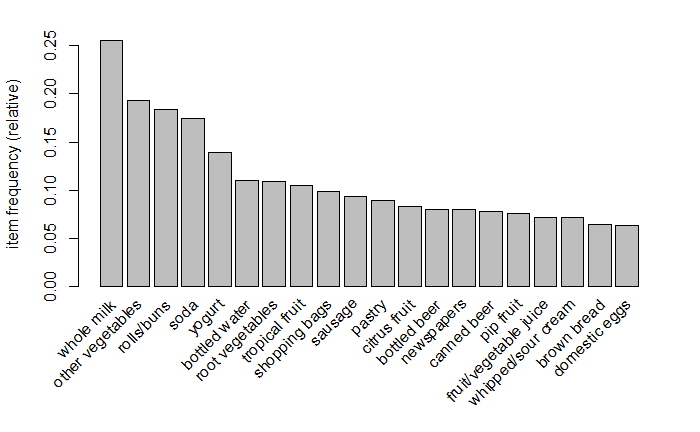

```r
itemFrequencyPlot(dataset, topN = 20)
```

In this diagram, we printed top 20 purchased items. We can change the value of topN variable and check more items. On Y axis, it shows the support of particular variable.

Now, let’s check the association rules by *Apriori Algorithm* -

```r
rules <- apriori(data = dataset, parameter = list(support = 0.03, confidence = 0.2))
```

```
Apriori

Parameter specification:
 confidence minval smax arem  aval originalSupport maxtime support minlen maxlen target   ext
        0.2    0.1    1 none FALSE            TRUE       5    0.03      1     10  rules FALSE

Algorithmic control:
 filter tree heap memopt load sort verbose
    0.1 TRUE TRUE  FALSE TRUE    2    TRUE

Absolute minimum support count: 295

set item appearances ...[0 item(s)] done [0.00s].
set transactions ...[169 item(s), 9835 transaction(s)] done [0.01s].
sorting and recoding items ... [44 item(s)] done [0.00s].
creating transaction tree ... done [0.01s].
checking subsets of size 1 2 3 done [0.03s].
writing ... [26 rule(s)] done [0.00s].
creating S4 object  ... done [0.01s].
```

From this, we can check that there are 26 association rules created by the algorithm. We can change the parameter containing minimum support and confidence level to increase the number of rules created. Generally, Support and confidence depends on the business problem.

Let’s check out the 26 association rules which are created.

```r
inspect(sort(rules, by = 'lift'))
```

```
     lhs                     rhs                support    confidence lift
[1]  {root vegetables}    => {other vegetables} 0.04738180 0.4347015  2.2466049
[2]  {other vegetables}   => {root vegetables}  0.04738180 0.2448765  2.2466049
[3]  {sausage}            => {rolls/buns}       0.03060498 0.3257576  1.7710480
[4]  {tropical fruit}     => {other vegetables} 0.03589222 0.3420543  1.7677896
[5]  {whipped/sour cream} => {whole milk}       0.03223183 0.4496454  1.7597542
[6]  {root vegetables}    => {whole milk}       0.04890696 0.4486940  1.7560310
[7]  {yogurt}             => {other vegetables} 0.04341637 0.3112245  1.6084566
[8]  {other vegetables}   => {yogurt}           0.04341637 0.2243826  1.6084566
[9]  {tropical fruit}     => {whole milk}       0.04229792 0.4031008  1.5775950
[10] {yogurt}             => {whole milk}       0.05602440 0.4016035  1.5717351
[11] {whole milk}         => {yogurt}           0.05602440 0.2192598  1.5717351
[12] {pip fruit}          => {whole milk}       0.03009659 0.3978495  1.5570432
[13] {other vegetables}   => {whole milk}       0.07483477 0.3867578  1.5136341
[14] {whole milk}         => {other vegetables} 0.07483477 0.2928770  1.5136341
[15] {pastry}             => {whole milk}       0.03324860 0.3737143  1.4625865
[16] {citrus fruit}       => {whole milk}       0.03050330 0.3685504  1.4423768
[17] {yogurt}             => {rolls/buns}       0.03436706 0.2463557  1.3393633
[18] {bottled water}      => {whole milk}       0.03426538 0.3103131  1.2144565
[19] {rolls/buns}         => {whole milk}       0.05663447 0.3079049  1.2050318
[20] {whole milk}         => {rolls/buns}       0.05663447 0.2216474  1.2050318
[21] {rolls/buns}         => {other vegetables} 0.04260295 0.2316197  1.1970465
[22] {other vegetables}   => {rolls/buns}       0.04260295 0.2201787  1.1970465
[23] {soda}               => {rolls/buns}       0.03833249 0.2198251  1.1951242
[24] {rolls/buns}         => {soda}             0.03833249 0.2084024  1.1951242
[25] {}                   => {whole milk}       0.25551601 0.2555160  1.0000000
[26] {soda}               => {whole milk}       0.04006101 0.2297376  0.8991124
```

These rules represent the probability of purchase of *rhs* product when *lhs* product is chosen.

For example - From the third rule -

[3] {sausage} => {rolls/buns} 0.03060498 0.3257576 1.7710480

Lift is mentioned as 1.77 which means that probability of purchase of *rolls/buns*, when *sausage* is purchased, is 77% more than other items.

Let’s visualize the rules -

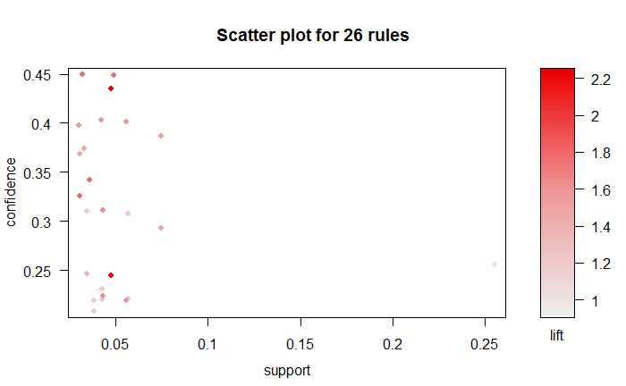

```r
library(arulesViz)
plot(rules)
```

Graph plot of the rules can generated by-

```r
plot(rules,method="graph",interactive=TRUE,shading=NA)
```

So, with this approach we can solve the business problem of which product can be shown as recomendation.